# Motor Trends

Nikhil Singhal

September 27, 2015

# Article

This month in Motor Trend, we have been following the mountain cars racing all over the bumps. While we were following the several racing events organized all over the country, many racing enthusiasts around us were pondering on what the mileage for these cars would be (for lesser pit stops) and what to tweak in the cars to get the most out of them.

So we collected information about all the mountain cars whizzing by in the event and have used it to answer our reader’s questions. We collected information about:

- Engine: *Cylinders*, *Engine Displacement*, *Horse Power*
- Chassis & Performance: *Weight*, *Rear Axle Ratio*, *1/4 Mile Time*
- Components: *V/S*, *Automatic Transmission*, *Gears*, *Carburetors*

There was a certain belief going on in the tracks that since manual transmissions give more control to the driver, which they leverage to extract more power at lower gears hence reducing the mileage. We found that although type of transmission IS a factor in mileage, but that isn’t alone in effecting it. Mileage also depends on the cylinders, horespower, weight and the time it takes for the car to cover 1/4 mile.

*(Page 1)*

# Appendix

## Explorartory Data Analysis

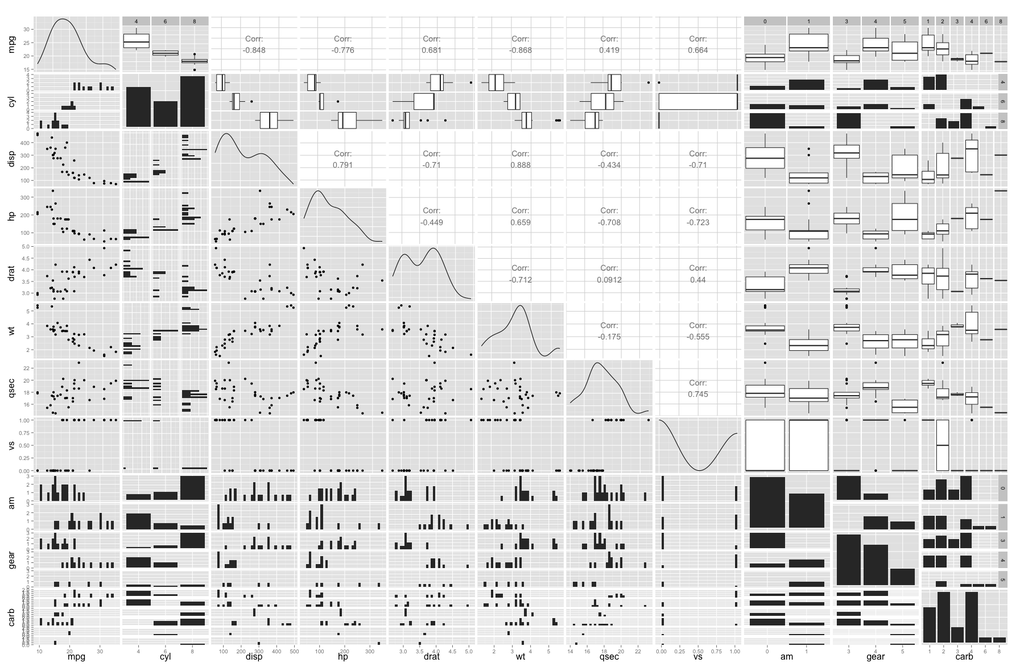

**General Observations:**

## Model Selection

|  | cyl6 | cyl8 | disp | hp | drat | wt | qsec | vs1 | am1 | gear4 | gear5 | carb2 | carb3 | carb4 | carb6 | carb8 |
| --- | --- | --- | --- | --- | --- | --- | --- | --- | --- | --- | --- | --- | --- | --- | --- | --- |
| 1 ( 1 ) |  |  |  |  |  | * |  |  |  |  |  |  |  |  |  |  |
| 1 ( 2 ) |  |  | * |  |  |  |  |  |  |  |  |  |  |  |  |  |
| 2 ( 1 ) |  |  |  | * |  | * |  |  |  |  |  |  |  |  |  |  |
| 2 ( 2 ) |  |  |  |  |  | * | * |  |  |  |  |  |  |  |  |  |
| 3 ( 1 ) |  |  |  |  |  | * | * |  | * |  |  |  |  |  |  |  |
| 3 ( 2 ) | * |  |  | * |  | * |  |  |  |  |  |  |  |  |  |  |
| 4 ( 1 ) | * |  |  | * |  | * |  |  | * |  |  |  |  |  |  |  |
| 4 ( 2 ) |  |  |  | * |  | * | * |  | * |  |  |  |  |  |  |  |
| 5 ( 1 ) | * |  |  | * |  | * |  | * | * |  |  |  |  |  |  |  |
| 5 ( 2 ) | * |  |  | * |  | * | * |  | * |  |  |  |  |  |  |  |
| 6 ( 1 ) | * |  |  | * |  | * |  | * | * |  | * |  |  |  |  |  |
| 6 ( 2 ) | * |  |  | * |  | * | * |  | * |  | * |  |  |  |  |  |
| 7 ( 1 ) |  | * |  | * |  | * | * | * | * |  | * |  |  |  |  |  |
| 7 ( 2 ) | * |  |  | * |  | * | * | * | * |  | * |  |  |  |  |  |
| 8 ( 1 ) | * |  | * | * |  | * |  |  |  | * | * | * |  |  |  | * |
| 8 ( 2 ) | * |  | * | * |  | * |  |  |  | * | * | * |  | * |  |  |
| 9 ( 1 ) | * |  | * | * |  | * |  | * |  | * | * | * |  | * |  |  |
| 9 ( 2 ) | * |  | * | * |  | * | * |  |  | * | * | * |  |  |  | * |
| 10 ( 1 ) | * |  | * | * | * | * |  | * |  | * | * | * |  | * |  |  |
| 10 ( 2 ) | * |  | * | * | * | * | * |  |  | * | * | * |  | * |  |  |
| 11 ( 1 ) | * |  | * | * |  | * |  | * |  | * | * | * | * |  | * | * |
| 11 ( 2 ) | * |  | * | * | * | * |  | * |  | * | * | * |  | * |  | * |
| 12 ( 1 ) | * |  | * | * | * | * |  | * |  | * | * | * | * |  | * | * |
| 12 ( 2 ) | * |  | * | * |  | * | * | * | * |  | * |  | * | * | * | * |
| 13 ( 1 ) | * |  | * | * | * | * | * | * | * |  | * |  | * | * | * | * |
| 13 ( 2 ) | * | * | * | * | * | * |  | * |  | * | * | * | * |  | * | * |
| 14 ( 1 ) | * |  | * | * | * | * | * | * | * | * | * | * | * |  | * | * |
| 14 ( 2 ) | * |  | * | * | * | * | * | * | * |  | * | * | * | * | * | * |
| 15 ( 1 ) | * |  | * | * | * | * | * | * | * | * | * | * | * | * | * | * |
| 15 ( 2 ) | * | * | * | * | * | * | * | * | * | * | * | * | * |  | * | * |
| 16 ( 1 ) | * | * | * | * | * | * | * | * | * | * | * | * | * | * | * | * |

*(Page 2)*

## Analysis

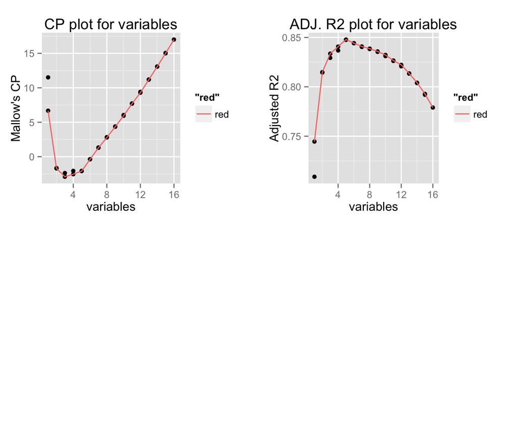

**Interpretation:**

- In the Mallow’s CP graph, the models with 3-5 regressor variables are the ones which have the least values. Hence, these are the models which are the most precise.
- In the adjusted R^2 graph, the models with the 4-6 regressor variables are the ones which explain the most amount of variation. The 5 variable model is the one with the highest variance explanation.
- In the Model Selection table, two best models for a particular number of variables have been displayed. And in both the graphs for 5 variable model, the readings coincide indicating that both the models can be used. (Going with model 5(2))

## MultiVariable Regression

```
##                 Estimate  Std. Error     t value    Pr(>|t|)
## (Intercept)  21.57616508 11.27271090  1.91401742 0.067132106
## factor(cyl)6 -1.90949640  1.72992011 -1.10380611 0.280188887
## factor(cyl)8 -0.22716240  2.87047074 -0.07913768 0.937553171
## hp           -0.02480654  0.01514918 -1.63748374 0.114056916
## wt           -2.96274129  0.97728243 -3.03161217 0.005595827
## qsec          0.61917236  0.55987340  1.10591494 0.279292531
## factor(am)1   2.83269554  1.67019936  1.69602241 0.102301456
```

**Interpretation:**

```
##              Estimate Std. Error   t value     Pr(>|t|)
## (Intercept) 17.147368   1.124603 15.247492 1.133983e-15
## factor(am)1  7.244939   1.764422  4.106127 2.850207e-04
```

**Interpretation:**

```
## Analysis of Variance Table
##
## Model 1: mpg ~ factor(cyl) + hp + wt + qsec + factor(am)
## Model 2: mpg ~ factor(am)
##   Res.Df    RSS Df Sum of Sq      F   Pr(>F)
## 1     25 143.98
## 2     30 720.90 -5   -576.91 20.034 5.08e-08 ***
## ---
## Signif. codes:  0 '***' 0.001 '**' 0.01 '*' 0.05 '.' 0.1 ' ' 1
```

**Interpretation:**

- The F statistic is quite large and the *p-value* is extremely low for our simple Model 2, which indicates that our Model 1 is correct.

  *(Page 3)*

## Residuals & Diagnostics

```
## geom_smooth: method="auto" and size of largest group is <1000, so using loess. Use 'method = x' to change the smoothing method.
```

[figure not shown]

**Interpretation:**

- The residual plot shows a near horizontal spread of residues showing a good fit of the regression model.
- The qq-plot shows that the errors are normally distributed.

The cars which have the most leverage on the regression line are (using hatvalues):

| Merc 240D | 0.2868312 |
| --- | --- |
| Lincoln Continental | 0.2956917 |
| Merc 230 | 0.4606154 |
| Maserati Bora | 0.5315176 |

## Effect Size

```
## [1] "Effect Size:  -1.41"
```

```
## [1] "Conf Int:  4.7"
```

**Interpretation:**

  *(Page 4)*